# Time Series: A First Course with Bootstrap Starter

# Lesson 3-2: Linear Filters

- A *linear filter* maps an input time series $\{ X_t \}$ to an output time series $\{ Y_t \}$ by taking a linear combination of past, present, and future observations:
  $$Y_t = \sum_{k \in {\mathbb Z}} \psi_k \, X_{t-k}.$$
  The *filter coefficients* (or *filter weights*) are $\{ \psi_k \}$. Note the convention that $\psi_k$ weights an observation occurring $k$ time points in the past (viewing time $t$ as the present).

## Example 3.2.5. Simple Moving Average

- Recall from nonparametric regression, we may estimate a slowly-changing mean via averaging over neighboring values:
  $$\frac{1}{2m+1} \sum_{k = -m}^m X_{t-k}.$$
  This weights the past $m$ and the future $m$ observations equally, and is an example of a linear filter. It also called a *moving average*, because the observations are averaged (over a window of $2m+1$ time points) in a way that moves over the time series. A *simple moving average* has equal weights (a general moving average could have unequal weights).

## Linear Time Series

- A time series $\{ Y_t \}$ is said to be *linear* if it is defined as the output of a linear filter (with coefficients $\{ \psi_k \}$) applied to $\{ X_t \}$, and $X_t \sim i.i.d.(\mu, \sigma^2)$.
- The mean of $Y_t$ is
  $${\mathbb E} [Y_t] = \mu \, \sum_{k \in {\mathbb Z}} \psi_k.$$
- The autocovariance of $\{ Y_t \}$ is
  $$\mbox{Cov} [ Y_t, Y_{t-h}] = \sum_{j,k \in {\mathbb Z}} \psi_j \psi_k
  \mbox{Cov} [X_{t-j}, X_{t-h-k}]
  = \sigma^2 \, \sum_{k \in {\mathbb Z}} \psi_k \psi_{k+h}.$$
  This calculation is obtained by seeing that $\mbox{Cov} [X_{t-j}, X_{t-h-k}]$ is zero unless $j=k+h$, in which case it equals $\sigma^2$.

## Smoothing of Population

- We apply a simple moving average to U.S. Population, using the R *filter* function.
- Overlay different choices of $m$.

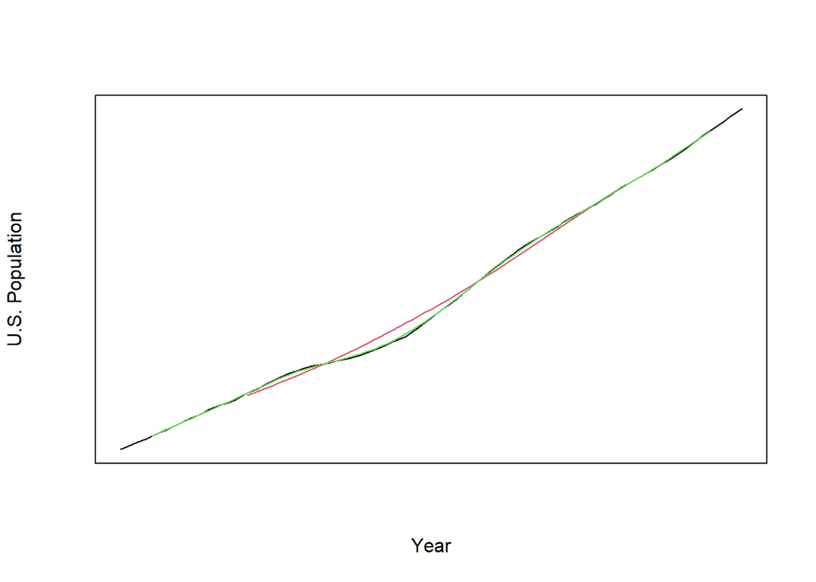

```r
pop <- read.table("USpop.dat")
pop <- ts(pop, start = 1901)

m <- 20
ma.weights <- rep(1,2*m+1)/(2*m+1)
pop.trend1 <- stats::filter(pop,ma.weights,method="convolution",sides=2)

m <- 5
ma.weights <- rep(1,2*m+1)/(2*m+1)
pop.trend2 <- stats::filter(pop,ma.weights,method="convolution",sides=2)

plot(pop,xlab="Year",ylab="U.S. Population",col=1,lwd=1,yaxt="n",xaxt="n")
lines(ts(pop.trend1,start=1901,frequency=1),lty=1,lwd=1,col=2)
lines(ts(pop.trend2,start=1901,frequency=1),lty=1,lwd=1,col=3)
```